# Risk Factor Analysis

## Outcome Variable

**Outcome Variable:** ever_wasted

## Predictor Variables

**Intervention Variable:** mwtkg

**Adjustment Set:**

unadjusted

## Stratifying Variables

The analysis was stratified on these variable(s):

- agecat
- studyid
- country

## Data Summary

| agecat | studyid | country | mwtkg | ever_wasted | n_cell | n |
| --- | --- | --- | --- | --- | --- | --- |
| 0-24 months | iLiNS-Zinc | BURKINA FASO | >=58 kg | 0 | 764 | 3217 |
| 0-24 months | iLiNS-Zinc | BURKINA FASO | >=58 kg | 1 | 173 | 3217 |
| 0-24 months | iLiNS-Zinc | BURKINA FASO | <52 kg | 0 | 865 | 3217 |
| 0-24 months | iLiNS-Zinc | BURKINA FASO | <52 kg | 1 | 336 | 3217 |
| 0-24 months | iLiNS-Zinc | BURKINA FASO | [52-58) kg | 0 | 855 | 3217 |
| 0-24 months | iLiNS-Zinc | BURKINA FASO | [52-58) kg | 1 | 224 | 3217 |
| 0-24 months | LCNI-5 | MALAWI | >=58 kg | 0 | 109 | 838 |
| 0-24 months | LCNI-5 | MALAWI | >=58 kg | 1 | 5 | 838 |
| 0-24 months | LCNI-5 | MALAWI | <52 kg | 0 | 457 | 838 |
| 0-24 months | LCNI-5 | MALAWI | <52 kg | 1 | 47 | 838 |
| 0-24 months | LCNI-5 | MALAWI | [52-58) kg | 0 | 206 | 838 |
| 0-24 months | LCNI-5 | MALAWI | [52-58) kg | 1 | 14 | 838 |
| 0-24 months | MAL-ED | BANGLADESH | >=58 kg | 0 | 39 | 254 |
| 0-24 months | MAL-ED | BANGLADESH | >=58 kg | 1 | 9 | 254 |
| 0-24 months | MAL-ED | BANGLADESH | <52 kg | 0 | 97 | 254 |
| 0-24 months | MAL-ED | BANGLADESH | <52 kg | 1 | 65 | 254 |
| 0-24 months | MAL-ED | BANGLADESH | [52-58) kg | 0 | 33 | 254 |
| 0-24 months | MAL-ED | BANGLADESH | [52-58) kg | 1 | 11 | 254 |
| 0-24 months | MAL-ED | BRAZIL | >=58 kg | 0 | 132 | 221 |
| 0-24 months | MAL-ED | BRAZIL | >=58 kg | 1 | 11 | 221 |
| 0-24 months | MAL-ED | BRAZIL | <52 kg | 0 | 40 | 221 |
| 0-24 months | MAL-ED | BRAZIL | <52 kg | 1 | 2 | 221 |
| 0-24 months | MAL-ED | BRAZIL | [52-58) kg | 0 | 30 | 221 |
| 0-24 months | MAL-ED | BRAZIL | [52-58) kg | 1 | 6 | 221 |
| 0-24 months | MAL-ED | INDIA | >=58 kg | 0 | 31 | 242 |
| 0-24 months | MAL-ED | INDIA | >=58 kg | 1 | 11 | 242 |
| 0-24 months | MAL-ED | INDIA | <52 kg | 0 | 66 | 242 |
| 0-24 months | MAL-ED | INDIA | <52 kg | 1 | 84 | 242 |
| 0-24 months | MAL-ED | INDIA | [52-58) kg | 0 | 28 | 242 |
| 0-24 months | MAL-ED | INDIA | [52-58) kg | 1 | 22 | 242 |

[output cut: 252 more lines]

The following strata were considered:

- agecat: 0-24 months, studyid: iLiNS-Zinc, country: BURKINA FASO
- agecat: 0-24 months, studyid: LCNI-5, country: MALAWI
- agecat: 0-24 months, studyid: MAL-ED, country: BANGLADESH
- agecat: 0-24 months, studyid: MAL-ED, country: BRAZIL
- agecat: 0-24 months, studyid: MAL-ED, country: INDIA
- agecat: 0-24 months, studyid: MAL-ED, country: NEPAL
- agecat: 0-24 months, studyid: MAL-ED, country: PERU
- agecat: 0-24 months, studyid: MAL-ED, country: SOUTH AFRICA
- agecat: 0-24 months, studyid: MAL-ED, country: TANZANIA, UNITED REPUBLIC OF
- agecat: 0-24 months, studyid: NIH-Birth, country: BANGLADESH
- agecat: 0-24 months, studyid: NIH-Crypto, country: BANGLADESH
- agecat: 0-24 months, studyid: PROBIT, country: BELARUS
- agecat: 0-24 months, studyid: PROVIDE, country: BANGLADESH
- agecat: 0-24 months, studyid: SAS-CompFeed, country: INDIA
- agecat: 0-24 months, studyid: TanzaniaChild2, country: TANZANIA, UNITED REPUBLIC OF
- agecat: 0-24 months, studyid: ZVITAMBO, country: ZIMBABWE
- agecat: 0-6 months, studyid: LCNI-5, country: MALAWI
- agecat: 0-6 months, studyid: MAL-ED, country: BANGLADESH
- agecat: 0-6 months, studyid: MAL-ED, country: BRAZIL
- agecat: 0-6 months, studyid: MAL-ED, country: INDIA
- agecat: 0-6 months, studyid: MAL-ED, country: NEPAL
- agecat: 0-6 months, studyid: MAL-ED, country: PERU
- agecat: 0-6 months, studyid: MAL-ED, country: SOUTH AFRICA
- agecat: 0-6 months, studyid: MAL-ED, country: TANZANIA, UNITED REPUBLIC OF
- agecat: 0-6 months, studyid: NIH-Birth, country: BANGLADESH
- agecat: 0-6 months, studyid: NIH-Crypto, country: BANGLADESH
- agecat: 0-6 months, studyid: PROBIT, country: BELARUS
- agecat: 0-6 months, studyid: PROVIDE, country: BANGLADESH
- agecat: 0-6 months, studyid: SAS-CompFeed, country: INDIA
- agecat: 0-6 months, studyid: TanzaniaChild2, country: TANZANIA, UNITED REPUBLIC OF
- agecat: 0-6 months, studyid: ZVITAMBO, country: ZIMBABWE
- agecat: 6-24 months, studyid: iLiNS-Zinc, country: BURKINA FASO
- agecat: 6-24 months, studyid: LCNI-5, country: MALAWI
- agecat: 6-24 months, studyid: MAL-ED, country: BANGLADESH
- agecat: 6-24 months, studyid: MAL-ED, country: BRAZIL
- agecat: 6-24 months, studyid: MAL-ED, country: INDIA
- agecat: 6-24 months, studyid: MAL-ED, country: NEPAL
- agecat: 6-24 months, studyid: MAL-ED, country: PERU
- agecat: 6-24 months, studyid: MAL-ED, country: SOUTH AFRICA
- agecat: 6-24 months, studyid: MAL-ED, country: TANZANIA, UNITED REPUBLIC OF
- agecat: 6-24 months, studyid: NIH-Birth, country: BANGLADESH
- agecat: 6-24 months, studyid: NIH-Crypto, country: BANGLADESH
- agecat: 6-24 months, studyid: PROBIT, country: BELARUS
- agecat: 6-24 months, studyid: PROVIDE, country: BANGLADESH
- agecat: 6-24 months, studyid: SAS-CompFeed, country: INDIA
- agecat: 6-24 months, studyid: TanzaniaChild2, country: TANZANIA, UNITED REPUBLIC OF
- agecat: 6-24 months, studyid: ZVITAMBO, country: ZIMBABWE

### Dropped Strata

Some strata were dropped due to rare outcomes:

- agecat: 0-24 months, studyid: MAL-ED, country: BRAZIL
- agecat: 0-6 months, studyid: LCNI-5, country: MALAWI
- agecat: 0-6 months, studyid: MAL-ED, country: BRAZIL
- agecat: 0-6 months, studyid: MAL-ED, country: PERU
- agecat: 0-6 months, studyid: MAL-ED, country: SOUTH AFRICA
- agecat: 0-6 months, studyid: MAL-ED, country: TANZANIA, UNITED REPUBLIC OF
- agecat: 6-24 months, studyid: MAL-ED, country: BANGLADESH
- agecat: 6-24 months, studyid: MAL-ED, country: BRAZIL
- agecat: 6-24 months, studyid: MAL-ED, country: INDIA
- agecat: 6-24 months, studyid: MAL-ED, country: PERU
- agecat: 6-24 months, studyid: MAL-ED, country: SOUTH AFRICA
- agecat: 6-24 months, studyid: MAL-ED, country: TANZANIA, UNITED REPUBLIC OF

## Methods Detail

We’re interested in the causal parameters $E[Y_a]$ for all values of $a \in \mathcal{A}$. These parameters represent the mean outcome if, possibly contrary to fact, we intervened to set all units to have $A=a$. Under the randomization and positivity assumptions, these are identified by the statistical parameters $\psi_a=E_W[E_{Y|A,W}(Y|A=a,W)]$. In addition, we’re interested in the mean of $Y$, $E[Y]$ under no intervention (the observed mean). We will estimate these parameters by using SuperLearner to fit the relevant likelihood factors – $E_{Y|A,W}(Y|A=a,W)$ and $p(A=a|W)$, and then updating our likelihood fit using a joint TMLE.

For unadjusted analyses ($W=\{\}$), initial likelihoods were estimated using Lrnr_glm to estimate the simple $E(Y|A)$ and Lrnr_mean to estimate $p(A)$. For adjusted analyses, a small library containing Lrnr_glmnet, Lrnr_xgboost, and Lrnr_mean was used.

Having estimated these parameters, we will then use the delta method to estimate relative risks and attributable risks relative to a prespecified baseline level of $A$.

# Results Detail

## Results Plots

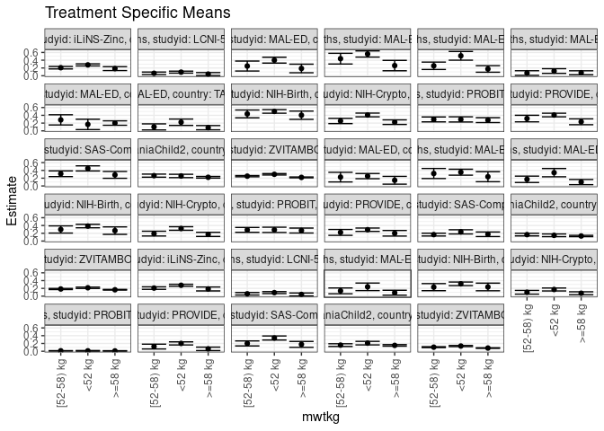

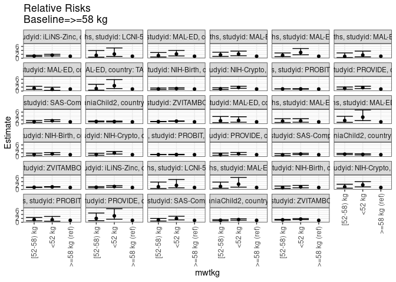

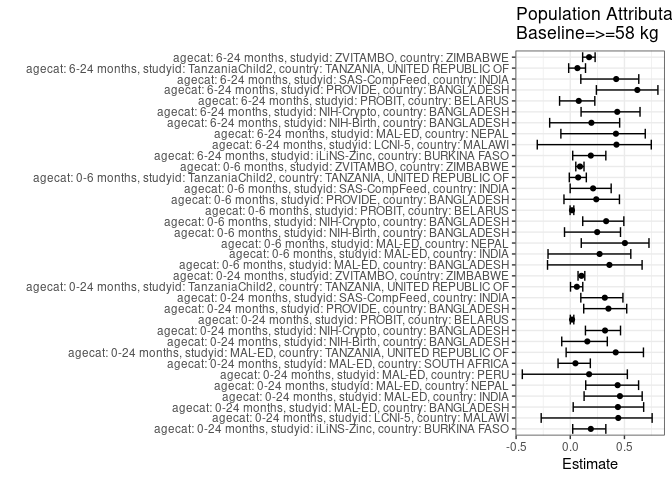

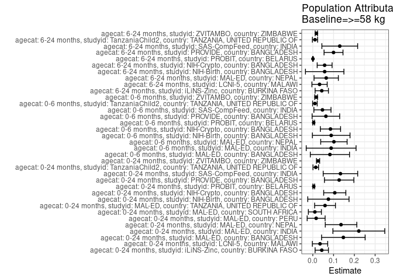

## Results Table

### Parameter: TSM

| agecat | studyid | country | intervention_level | baseline_level | estimate | ci_lower | ci_upper |
| --- | --- | --- | --- | --- | --- | --- | --- |
| 0-24 months | iLiNS-Zinc | BURKINA FASO | >=58 kg | NA | 0.1846318 | 0.1344824 | 0.2347812 |
| 0-24 months | iLiNS-Zinc | BURKINA FASO | <52 kg | NA | 0.2797669 | 0.2532143 | 0.3063194 |
| 0-24 months | iLiNS-Zinc | BURKINA FASO | [52-58) kg | NA | 0.2075996 | 0.1755168 | 0.2396824 |
| 0-24 months | LCNI-5 | MALAWI | >=58 kg | NA | 0.0438596 | 0.0062458 | 0.0814735 |
| 0-24 months | LCNI-5 | MALAWI | <52 kg | NA | 0.0932540 | 0.0678519 | 0.1186560 |
| 0-24 months | LCNI-5 | MALAWI | [52-58) kg | NA | 0.0636364 | 0.0313610 | 0.0959117 |
| 0-24 months | MAL-ED | BANGLADESH | >=58 kg | NA | 0.1875000 | 0.0768640 | 0.2981360 |
| 0-24 months | MAL-ED | BANGLADESH | <52 kg | NA | 0.4012346 | 0.3256079 | 0.4768612 |
| 0-24 months | MAL-ED | BANGLADESH | [52-58) kg | NA | 0.2500000 | 0.1218027 | 0.3781973 |
| 0-24 months | MAL-ED | INDIA | >=58 kg | NA | 0.2619048 | 0.1286599 | 0.3951496 |
| 0-24 months | MAL-ED | INDIA | <52 kg | NA | 0.5600000 | 0.4803984 | 0.6396016 |
| 0-24 months | MAL-ED | INDIA | [52-58) kg | NA | 0.4400000 | 0.3021259 | 0.5778741 |
| 0-24 months | MAL-ED | NEPAL | >=58 kg | NA | 0.1750000 | 0.0915621 | 0.2584379 |
| 0-24 months | MAL-ED | NEPAL | <52 kg | NA | 0.5131579 | 0.4005484 | 0.6257674 |
| 0-24 months | MAL-ED | NEPAL | [52-58) kg | NA | 0.2560976 | 0.1614267 | 0.3507684 |
| 0-24 months | MAL-ED | PERU | >=58 kg | NA | 0.0769231 | 0.0256217 | 0.1282244 |
| 0-24 months | MAL-ED | PERU | <52 kg | NA | 0.1217391 | 0.0618737 | 0.1816046 |
| 0-24 months | MAL-ED | PERU | [52-58) kg | NA | 0.0704225 | 0.0108059 | 0.1300392 |
| 0-24 months | MAL-ED | SOUTH AFRICA | >=58 kg | NA | 0.2010309 | 0.1445308 | 0.2575311 |
| 0-24 months | MAL-ED | SOUTH AFRICA | <52 kg | NA | 0.1666667 | 0.0330604 | 0.3002730 |
| 0-24 months | MAL-ED | SOUTH AFRICA | [52-58) kg | NA | 0.2826087 | 0.1522483 | 0.4129691 |
| 0-24 months | MAL-ED | TANZANIA, UNITED REPUBLIC OF | >=58 kg | NA | 0.0816327 | 0.0273170 | 0.1359483 |
| 0-24 months | MAL-ED | TANZANIA, UNITED REPUBLIC OF | <52 kg | NA | 0.2222222 | 0.1401678 | 0.3042766 |
| 0-24 months | MAL-ED | TANZANIA, UNITED REPUBLIC OF | [52-58) kg | NA | 0.1016949 | 0.0244209 | 0.1789689 |
| 0-24 months | NIH-Birth | BANGLADESH | >=58 kg | NA | 0.4024390 | 0.2962131 | 0.5086650 |
| 0-24 months | NIH-Birth | BANGLADESH | <52 kg | NA | 0.5000000 | 0.4536631 | 0.5463369 |
| 0-24 months | NIH-Birth | BANGLADESH | [52-58) kg | NA | 0.4361702 | 0.3358394 | 0.5365011 |
| 0-24 months | NIH-Crypto | BANGLADESH | >=58 kg | NA | 0.2239583 | 0.1649503 | 0.2829664 |
| 0-24 months | NIH-Crypto | BANGLADESH | <52 kg | NA | 0.4088670 | 0.3610143 | 0.4567197 |
| 0-24 months | NIH-Crypto | BANGLADESH | [52-58) kg | NA | 0.2547771 | 0.1865731 | 0.3229810 |

[output cut: 75 more lines]

### Parameter: E(Y)

| agecat | studyid | country | intervention_level | baseline_level | estimate | ci_lower | ci_upper |
| --- | --- | --- | --- | --- | --- | --- | --- |
| 0-24 months | iLiNS-Zinc | BURKINA FASO | NA | NA | 0.2278520 | 0.2008644 | 0.2548397 |
| 0-24 months | LCNI-5 | MALAWI | NA | NA | 0.0787589 | 0.0605107 | 0.0970072 |
| 0-24 months | MAL-ED | BANGLADESH | NA | NA | 0.3346457 | 0.2765014 | 0.3927899 |
| 0-24 months | MAL-ED | INDIA | NA | NA | 0.4834711 | 0.4203794 | 0.5465628 |
| 0-24 months | MAL-ED | NEPAL | NA | NA | 0.3109244 | 0.2519946 | 0.3698541 |
| 0-24 months | MAL-ED | PERU | NA | NA | 0.0931034 | 0.0596022 | 0.1266047 |
| 0-24 months | MAL-ED | SOUTH AFRICA | NA | NA | 0.2111111 | 0.1623431 | 0.2598792 |
| 0-24 months | MAL-ED | TANZANIA, UNITED REPUBLIC OF | NA | NA | 0.1406250 | 0.0979572 | 0.1832928 |
| 0-24 months | NIH-Birth | BANGLADESH | NA | NA | 0.4775641 | 0.4383415 | 0.5167867 |
| 0-24 months | NIH-Crypto | BANGLADESH | NA | NA | 0.3298013 | 0.2962438 | 0.3633589 |
| 0-24 months | PROBIT | BELARUS | NA | NA | 0.2805693 | 0.2183906 | 0.3427479 |
| 0-24 months | PROVIDE | BANGLADESH | NA | NA | 0.3602392 | 0.3238339 | 0.3966444 |
| 0-24 months | SAS-CompFeed | INDIA | NA | NA | 0.4175017 | 0.3589990 | 0.4760043 |
| 0-24 months | TanzaniaChild2 | TANZANIA, UNITED REPUBLIC OF | NA | NA | 0.2372449 | 0.2200495 | 0.2544403 |
| 0-24 months | ZVITAMBO | ZIMBABWE | NA | NA | 0.2457915 | 0.2378059 | 0.2537772 |
| 0-6 months | MAL-ED | BANGLADESH | NA | NA | 0.2283465 | 0.1766220 | 0.2800709 |
| 0-6 months | MAL-ED | INDIA | NA | NA | 0.3264463 | 0.2672449 | 0.3856476 |
| 0-6 months | MAL-ED | NEPAL | NA | NA | 0.2016807 | 0.1505956 | 0.2527658 |
| 0-6 months | NIH-Birth | BANGLADESH | NA | NA | 0.3569132 | 0.3192325 | 0.3945938 |
| 0-6 months | NIH-Crypto | BANGLADESH | NA | NA | 0.2569536 | 0.2257649 | 0.2881424 |
| 0-6 months | PROBIT | BELARUS | NA | NA | 0.2747604 | 0.2123223 | 0.3371985 |
| 0-6 months | PROVIDE | BANGLADESH | NA | NA | 0.2630792 | 0.2296894 | 0.2964690 |
| 0-6 months | SAS-CompFeed | INDIA | NA | NA | 0.2208054 | 0.1758216 | 0.2657892 |
| 0-6 months | TanzaniaChild2 | TANZANIA, UNITED REPUBLIC OF | NA | NA | 0.1403061 | 0.1262673 | 0.1543450 |
| 0-6 months | ZVITAMBO | ZIMBABWE | NA | NA | 0.1804281 | 0.1732799 | 0.1875764 |
| 6-24 months | iLiNS-Zinc | BURKINA FASO | NA | NA | 0.2278520 | 0.2008644 | 0.2548397 |
| 6-24 months | LCNI-5 | MALAWI | NA | NA | 0.0764563 | 0.0583018 | 0.0946108 |
| 6-24 months | MAL-ED | NEPAL | NA | NA | 0.1531915 | 0.1070438 | 0.1993392 |
| 6-24 months | NIH-Birth | BANGLADESH | NA | NA | 0.2933579 | 0.2549918 | 0.3317241 |
| 6-24 months | NIH-Crypto | BANGLADESH | NA | NA | 0.1315068 | 0.1069744 | 0.1560393 |
| 6-24 months | PROBIT | BELARUS | NA | NA | 0.0090817 | 0.0046144 | 0.0135489 |
| 6-24 months | PROVIDE | BANGLADESH | NA | NA | 0.1612378 | 0.1321259 | 0.1903497 |
| 6-24 months | SAS-CompFeed | INDIA | NA | NA | 0.3062998 | 0.2626026 | 0.3499970 |
| 6-24 months | TanzaniaChild2 | TANZANIA, UNITED REPUBLIC OF | NA | NA | 0.1612740 | 0.1450620 | 0.1774860 |
| 6-24 months | ZVITAMBO | ZIMBABWE | NA | NA | 0.0995484 | 0.0936035 | 0.1054934 |

### Parameter: RR

| agecat | studyid | country | intervention_level | baseline_level | estimate | ci_lower | ci_upper |
| --- | --- | --- | --- | --- | --- | --- | --- |
| 0-24 months | iLiNS-Zinc | BURKINA FASO | >=58 kg | >=58 kg | 1.0000000 | 1.0000000 | 1.000000 |
| 0-24 months | iLiNS-Zinc | BURKINA FASO | <52 kg | >=58 kg | 1.5152691 | 1.1564798 | 1.985370 |
| 0-24 months | iLiNS-Zinc | BURKINA FASO | [52-58) kg | >=58 kg | 1.1243980 | 0.8649036 | 1.461748 |
| 0-24 months | LCNI-5 | MALAWI | >=58 kg | >=58 kg | 1.0000000 | 1.0000000 | 1.000000 |
| 0-24 months | LCNI-5 | MALAWI | <52 kg | >=58 kg | 2.1261905 | 0.8646020 | 5.228632 |
| 0-24 months | LCNI-5 | MALAWI | [52-58) kg | >=58 kg | 1.4509091 | 0.5357128 | 3.929600 |
| 0-24 months | MAL-ED | BANGLADESH | >=58 kg | >=58 kg | 1.0000000 | 1.0000000 | 1.000000 |
| 0-24 months | MAL-ED | BANGLADESH | <52 kg | >=58 kg | 2.1399177 | 1.1518112 | 3.975693 |
| 0-24 months | MAL-ED | BANGLADESH | [52-58) kg | >=58 kg | 1.3333333 | 0.6101437 | 2.913704 |
| 0-24 months | MAL-ED | INDIA | >=58 kg | >=58 kg | 1.0000000 | 1.0000000 | 1.000000 |
| 0-24 months | MAL-ED | INDIA | <52 kg | >=58 kg | 2.1381818 | 1.2607642 | 3.626230 |
| 0-24 months | MAL-ED | INDIA | [52-58) kg | >=58 kg | 1.6800000 | 0.9243023 | 3.053546 |
| 0-24 months | MAL-ED | NEPAL | >=58 kg | >=58 kg | 1.0000000 | 1.0000000 | 1.000000 |
| 0-24 months | MAL-ED | NEPAL | <52 kg | >=58 kg | 2.9323308 | 1.7348713 | 4.956312 |
| 0-24 months | MAL-ED | NEPAL | [52-58) kg | >=58 kg | 1.4634146 | 0.8004866 | 2.675351 |
| 0-24 months | MAL-ED | PERU | >=58 kg | >=58 kg | 1.0000000 | 1.0000000 | 1.000000 |
| 0-24 months | MAL-ED | PERU | <52 kg | >=58 kg | 1.5826087 | 0.6910535 | 3.624394 |
| 0-24 months | MAL-ED | PERU | [52-58) kg | >=58 kg | 0.9154930 | 0.3116133 | 2.689640 |
| 0-24 months | MAL-ED | SOUTH AFRICA | >=58 kg | >=58 kg | 1.0000000 | 1.0000000 | 1.000000 |
| 0-24 months | MAL-ED | SOUTH AFRICA | <52 kg | >=58 kg | 0.8290598 | 0.3545375 | 1.938695 |
| 0-24 months | MAL-ED | SOUTH AFRICA | [52-58) kg | >=58 kg | 1.4057971 | 0.8191006 | 2.412726 |
| 0-24 months | MAL-ED | TANZANIA, UNITED REPUBLIC OF | >=58 kg | >=58 kg | 1.0000000 | 1.0000000 | 1.000000 |
| 0-24 months | MAL-ED | TANZANIA, UNITED REPUBLIC OF | <52 kg | >=58 kg | 2.7222222 | 1.2718747 | 5.826434 |
| 0-24 months | MAL-ED | TANZANIA, UNITED REPUBLIC OF | [52-58) kg | >=58 kg | 1.2457627 | 0.4537299 | 3.420371 |
| 0-24 months | NIH-Birth | BANGLADESH | >=58 kg | >=58 kg | 1.0000000 | 1.0000000 | 1.000000 |
| 0-24 months | NIH-Birth | BANGLADESH | <52 kg | >=58 kg | 1.2424242 | 0.9392374 | 1.643480 |
| 0-24 months | NIH-Birth | BANGLADESH | [52-58) kg | >=58 kg | 1.0838169 | 0.7636604 | 1.538196 |
| 0-24 months | NIH-Crypto | BANGLADESH | >=58 kg | >=58 kg | 1.0000000 | 1.0000000 | 1.000000 |
| 0-24 months | NIH-Crypto | BANGLADESH | <52 kg | >=58 kg | 1.8256387 | 1.3683797 | 2.435696 |
| 0-24 months | NIH-Crypto | BANGLADESH | [52-58) kg | >=58 kg | 1.1376092 | 0.7813886 | 1.656224 |

[output cut: 75 more lines]

### Parameter: PAR

| agecat | studyid | country | intervention_level | baseline_level | estimate | ci_lower | ci_upper |
| --- | --- | --- | --- | --- | --- | --- | --- |
| 0-24 months | iLiNS-Zinc | BURKINA FASO | >=58 kg | NA | 0.0432202 | 0.0111479 | 0.0752926 |
| 0-24 months | LCNI-5 | MALAWI | >=58 kg | NA | 0.0348993 | -0.0020178 | 0.0718164 |
| 0-24 months | MAL-ED | BANGLADESH | >=58 kg | NA | 0.1471457 | 0.0422895 | 0.2520018 |
| 0-24 months | MAL-ED | INDIA | >=58 kg | NA | 0.2215663 | 0.0967779 | 0.3463547 |
| 0-24 months | MAL-ED | NEPAL | >=58 kg | NA | 0.1359244 | 0.0600670 | 0.2117818 |
| 0-24 months | MAL-ED | PERU | >=58 kg | NA | 0.0161804 | -0.0270227 | 0.0593834 |
| 0-24 months | MAL-ED | SOUTH AFRICA | >=58 kg | NA | 0.0100802 | -0.0212756 | 0.0414360 |
| 0-24 months | MAL-ED | TANZANIA, UNITED REPUBLIC OF | >=58 kg | NA | 0.0589923 | 0.0088725 | 0.1091122 |
| 0-24 months | NIH-Birth | BANGLADESH | >=58 kg | NA | 0.0751251 | -0.0241559 | 0.1744060 |
| 0-24 months | NIH-Crypto | BANGLADESH | >=58 kg | NA | 0.1058430 | 0.0525785 | 0.1591075 |
| 0-24 months | PROBIT | BELARUS | >=58 kg | NA | 0.0046669 | 0.0004386 | 0.0088953 |
| 0-24 months | PROVIDE | BANGLADESH | >=58 kg | NA | 0.1269058 | 0.0561735 | 0.1976382 |
| 0-24 months | SAS-CompFeed | INDIA | >=58 kg | NA | 0.1330980 | 0.0501065 | 0.2160895 |
| 0-24 months | TanzaniaChild2 | TANZANIA, UNITED REPUBLIC OF | >=58 kg | NA | 0.0143452 | 0.0009053 | 0.0277850 |
| 0-24 months | ZVITAMBO | ZIMBABWE | >=58 kg | NA | 0.0254205 | 0.0177434 | 0.0330977 |
| 0-6 months | MAL-ED | BANGLADESH | >=58 kg | NA | 0.0825131 | -0.0118328 | 0.1768591 |
| 0-6 months | MAL-ED | INDIA | >=58 kg | NA | 0.0883510 | -0.0315761 | 0.2082782 |
| 0-6 months | MAL-ED | NEPAL | >=58 kg | NA | 0.1016807 | 0.0381826 | 0.1651787 |
| 0-6 months | NIH-Birth | BANGLADESH | >=58 kg | NA | 0.0886205 | -0.0019473 | 0.1791883 |
| 0-6 months | NIH-Crypto | BANGLADESH | >=58 kg | NA | 0.0850786 | 0.0363554 | 0.1338019 |
| 0-6 months | PROBIT | BELARUS | >=58 kg | NA | 0.0043061 | -0.0001695 | 0.0087817 |
| 0-6 months | PROVIDE | BANGLADESH | >=58 kg | NA | 0.0630792 | -0.0032855 | 0.1294439 |
| 0-6 months | SAS-CompFeed | INDIA | >=58 kg | NA | 0.0464934 | 0.0053360 | 0.0876509 |
| 0-6 months | TanzaniaChild2 | TANZANIA, UNITED REPUBLIC OF | >=58 kg | NA | 0.0102248 | -0.0008172 | 0.0212669 |
| 0-6 months | ZVITAMBO | ZIMBABWE | >=58 kg | NA | 0.0161744 | 0.0093097 | 0.0230391 |
| 6-24 months | iLiNS-Zinc | BURKINA FASO | >=58 kg | NA | 0.0432202 | 0.0111479 | 0.0752926 |
| 6-24 months | LCNI-5 | MALAWI | >=58 kg | NA | 0.0325967 | -0.0041856 | 0.0693789 |
| 6-24 months | MAL-ED | NEPAL | >=58 kg | NA | 0.0645839 | 0.0060879 | 0.1230799 |
| 6-24 months | NIH-Birth | BANGLADESH | >=58 kg | NA | 0.0572468 | -0.0352267 | 0.1497204 |
| 6-24 months | NIH-Crypto | BANGLADESH | >=58 kg | NA | 0.0570388 | 0.0211819 | 0.0928957 |
| 6-24 months | PROBIT | BELARUS | >=58 kg | NA | 0.0007094 | -0.0005813 | 0.0020001 |
| 6-24 months | PROVIDE | BANGLADESH | >=58 kg | NA | 0.0998343 | 0.0543326 | 0.1453359 |
| 6-24 months | SAS-CompFeed | INDIA | >=58 kg | NA | 0.1298292 | 0.0437584 | 0.2159000 |
| 6-24 months | TanzaniaChild2 | TANZANIA, UNITED REPUBLIC OF | >=58 kg | NA | 0.0106764 | -0.0018722 | 0.0232250 |
| 6-24 months | ZVITAMBO | ZIMBABWE | >=58 kg | NA | 0.0172939 | 0.0114994 | 0.0230884 |

### Parameter: PAF

| agecat | studyid | country | intervention_level | baseline_level | estimate | ci_lower | ci_upper |
| --- | --- | --- | --- | --- | --- | --- | --- |
| 0-24 months | iLiNS-Zinc | BURKINA FASO | >=58 kg | NA | 0.1896855 | 0.0225601 | 0.3282354 |
| 0-24 months | LCNI-5 | MALAWI | >=58 kg | NA | 0.4431154 | -0.2685075 | 0.7555233 |
| 0-24 months | MAL-ED | BANGLADESH | >=58 kg | NA | 0.4397059 | 0.0269915 | 0.6773620 |
| 0-24 months | MAL-ED | INDIA | >=58 kg | NA | 0.4582825 | 0.1274764 | 0.6636677 |
| 0-24 months | MAL-ED | NEPAL | >=58 kg | NA | 0.4371622 | 0.1425333 | 0.6305554 |
| 0-24 months | MAL-ED | PERU | >=58 kg | NA | 0.1737892 | -0.4426530 | 0.5268271 |
| 0-24 months | MAL-ED | SOUTH AFRICA | >=58 kg | NA | 0.0477482 | -0.1127541 | 0.1850999 |
| 0-24 months | MAL-ED | TANZANIA, UNITED REPUBLIC OF | >=58 kg | NA | 0.4195011 | -0.0382341 | 0.6754307 |
| 0-24 months | NIH-Birth | BANGLADESH | >=58 kg | NA | 0.1573089 | -0.0787476 | 0.3417104 |
| 0-24 months | NIH-Crypto | BANGLADESH | >=58 kg | NA | 0.3209296 | 0.1399941 | 0.4637983 |
| 0-24 months | PROBIT | BELARUS | >=58 kg | NA | 0.0166338 | 0.0004925 | 0.0325146 |
| 0-24 months | PROVIDE | BANGLADESH | >=58 kg | NA | 0.3522822 | 0.1241081 | 0.5210158 |
| 0-24 months | SAS-CompFeed | INDIA | >=58 kg | NA | 0.3187963 | 0.0973921 | 0.4858915 |
| 0-24 months | TanzaniaChild2 | TANZANIA, UNITED REPUBLIC OF | >=58 kg | NA | 0.0604657 | 0.0021480 | 0.1153750 |
| 0-24 months | ZVITAMBO | ZIMBABWE | >=58 kg | NA | 0.1034232 | 0.0717164 | 0.1340470 |
| 0-6 months | MAL-ED | BANGLADESH | >=58 kg | NA | 0.3613506 | -0.2099737 | 0.6629075 |
| 0-6 months | MAL-ED | INDIA | >=58 kg | NA | 0.2706450 | -0.2053628 | 0.5586733 |
| 0-6 months | MAL-ED | NEPAL | >=58 kg | NA | 0.5041667 | 0.1014472 | 0.7263926 |
| 0-6 months | NIH-Birth | BANGLADESH | >=58 kg | NA | 0.2482971 | -0.0532266 | 0.4634989 |
| 0-6 months | NIH-Crypto | BANGLADESH | >=58 kg | NA | 0.3311050 | 0.1149312 | 0.4944794 |
| 0-6 months | PROBIT | BELARUS | >=58 kg | NA | 0.0156721 | -0.0016213 | 0.0326669 |
| 0-6 months | PROVIDE | BANGLADESH | >=58 kg | NA | 0.2397727 | -0.0582110 | 0.4538466 |
| 0-6 months | SAS-CompFeed | INDIA | >=58 kg | NA | 0.2105630 | -0.0010937 | 0.3774701 |
| 0-6 months | TanzaniaChild2 | TANZANIA, UNITED REPUBLIC OF | >=58 kg | NA | 0.0728751 | -0.0090047 | 0.1481104 |
| 0-6 months | ZVITAMBO | ZIMBABWE | >=58 kg | NA | 0.0896447 | 0.0508954 | 0.1268120 |
| 6-24 months | iLiNS-Zinc | BURKINA FASO | >=58 kg | NA | 0.1896855 | 0.0225601 | 0.3282354 |
| 6-24 months | LCNI-5 | MALAWI | >=58 kg | NA | 0.4263436 | -0.3046507 | 0.7477627 |
| 6-24 months | MAL-ED | NEPAL | >=58 kg | NA | 0.4215893 | -0.0867215 | 0.6921392 |
| 6-24 months | NIH-Birth | BANGLADESH | >=58 kg | NA | 0.1951433 | -0.1902169 | 0.4557342 |
| 6-24 months | NIH-Crypto | BANGLADESH | >=58 kg | NA | 0.4337323 | 0.0997469 | 0.6438122 |
| 6-24 months | PROBIT | BELARUS | >=58 kg | NA | 0.0781121 | -0.0987192 | 0.2264837 |
| 6-24 months | PROVIDE | BANGLADESH | >=58 kg | NA | 0.6191742 | 0.2410369 | 0.8089126 |
| 6-24 months | SAS-CompFeed | INDIA | >=58 kg | NA | 0.4238632 | 0.0972969 | 0.6322892 |
| 6-24 months | TanzaniaChild2 | TANZANIA, UNITED REPUBLIC OF | >=58 kg | NA | 0.0662004 | -0.0147437 | 0.1406878 |
| 6-24 months | ZVITAMBO | ZIMBABWE | >=58 kg | NA | 0.1737236 | 0.1142323 | 0.2292191 |